# World Happiness Report - Comprehensive Analysis

Data Analysis Report

2025-11-02

# 1 Executive Summary

This report presents a comprehensive analysis of global happiness patterns across countries, examining the relationships between happiness scores and various socioeconomic factors including GDP per capita, social support, life expectancy, freedom, and corruption perceptions.

**Key Findings:**

- The global average happiness score is 5.45
- Finland ranks as the happiest country with a score of 7.74
- GDP per capita shows a strong positive correlation with happiness (r = 0.769)
- Social support is the strongest predictor of happiness (r = 0.818)
- Significant regional disparities exist, with North America and ANZ leading

# 2 Introduction

## 2.1 Background

Happiness and well-being are fundamental goals for individuals and societies worldwide. Understanding what contributes to national happiness helps policymakers design better interventions and allocate resources effectively.

## 2.2 Objectives

This analysis aims to:

1. Identify the happiest and least happy countries globally
2. Examine relationships between happiness and key socioeconomic indicators
3. Analyze regional patterns and disparities
4. Identify surprising cases (high GDP but low happiness, and vice versa)
5. Provide evidence-based policy recommendations

## 2.3 Data Overview

- **Total Countries Analyzed:** 173
- **Total Observations:** 1360
- **Time Period:** 2015 - 2024
- **Key Variables:** Happiness Score, GDP per Capita, Social Support, Life Expectancy, Freedom, Generosity, Corruption Perceptions

# 3 Top and Bottom Performing Countries

## 3.1 Top 10 Happiest Countries

Top 10 Happiest Countries

| Country | Region | Happiness Score | GDP per Capita | Social Support |
| --- | --- | --- | --- | --- |
| Finland | Western Europe | 7.74 | 8.61 | 0.97 |
| Denmark | Western Europe | 7.58 | 8.91 | 0.94 |
| Iceland | Western Europe | 7.53 | 8.79 | 1.00 |
| Sweden | Western Europe | 7.34 | 8.77 | 0.93 |
| Israel | Middle East and North Africa | 7.34 | 8.42 | 0.94 |
| Netherlands | Western Europe | 7.32 | 8.88 | 0.90 |
| Norway | Western Europe | 7.30 | 9.12 | 0.94 |
| Luxembourg | Western Europe | 7.12 | 10.00 | 0.84 |
| Switzerland | Western Europe | 7.06 | 9.20 | 0.88 |
| Australia | North America and ANZ | 7.06 | 8.66 | 0.90 |

**Interpretation:**

The top 10 happiest countries share several common characteristics:

- **Geographic Concentration:** Most are concentrated in Western Europe and North America/ANZ regions
- **Economic Prosperity:** All have relatively high GDP per capita scores (>8.4)
- **Strong Social Fabric:** High social support scores indicate robust community networks and family ties
- **Common Features:** These nations typically have strong democratic institutions, low corruption, high-quality healthcare, and comprehensive social safety nets

## 3.2 Bottom 10 Least Happy Countries

Bottom 10 Least Happy Countries

| Country | Region | Happiness Score | GDP per Capita | Social Support |
| --- | --- | --- | --- | --- |
| Afghanistan | South Asia | 1.72 | 2.93 | 0.00 |
| Lebanon | Middle East and North Africa | 2.71 | 6.43 | 0.36 |
| Central African Republic | Sub-Saharan Africa | 3.08 | 0.14 | 0.01 |
| Lesotho | Sub-Saharan Africa | 3.19 | 3.60 | 0.53 |
| Zimbabwe | Sub-Saharan Africa | 3.20 | 3.45 | 0.54 |
| Sierra Leone | Sub-Saharan Africa | 3.25 | 3.06 | 0.35 |
| South Sudan | Sub-Saharan Africa | 3.25 | 2.05 | 0.20 |
| Rwanda | Sub-Saharan Africa | 3.27 | 3.55 | 0.10 |
| Congo (Kinshasa) | Sub-Saharan Africa | 3.30 | 2.49 | 0.41 |
| Botswana | Sub-Saharan Africa | 3.38 | 6.75 | 0.60 |

**Interpretation:**

The least happy countries face multiple challenges:

- **Economic Hardship:** Significantly lower GDP per capita scores
- **Regional Patterns:** Concentration in Sub-Saharan Africa and conflict-affected regions
- **Weak Social Support:** Lower social support scores suggest fragmented community structures
- **Contributing Factors:** Many face ongoing conflicts, political instability, poor governance, inadequate healthcare, and limited economic opportunities

## 3.3 Visual Comparison

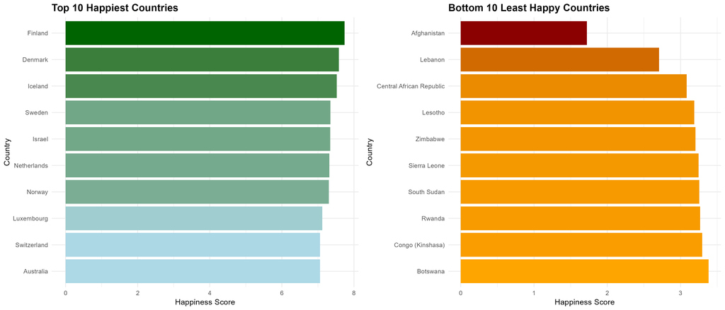

Top and Bottom 10 Countries by Happiness Score

**Graph Interpretation:**

The visualization clearly shows the stark contrast between the happiest and least happy nations. The happiness gap between the top and bottom countries is approximately 6 points, representing a massive disparity in quality of life, economic conditions, and social well-being.

# 4 Happiness and Economic Prosperity

## 4.1 GDP per Capita Analysis

GDP per capita is often considered a primary driver of national happiness. This section examines the relationship between economic prosperity and happiness.

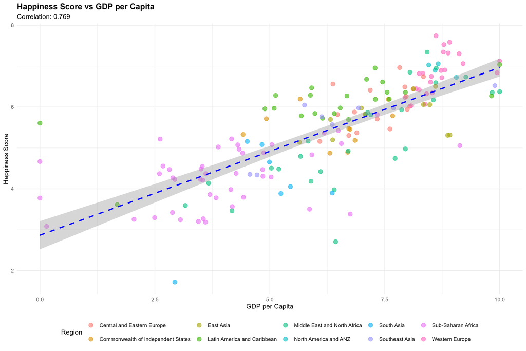

Relationship between Happiness and GDP per Capita

**Statistical Analysis:**

- **Correlation Coefficient:** r = 0.769 (strong positive correlation)
- **R-squared:** 0.592 (GDP explains 59.2% of happiness variance)

**Interpretation:**

The scatter plot reveals a clear positive relationship between GDP per capita and happiness scores. Countries with higher economic output per person tend to report greater happiness levels. However, the relationship is not perfectly linear, and several important patterns emerge:

1. **Diminishing Returns:** The relationship appears stronger at lower GDP levels, suggesting that economic growth has diminishing returns on happiness once basic needs are met
2. **Threshold Effect:** Beyond a certain GDP level (~7.0), additional wealth contributes less dramatically to happiness
3. **Outliers Exist:** Some countries deviate significantly from the trend line, indicating that factors beyond GDP matter substantially

## 4.2 Surprising Cases

### 4.2.1 High GDP but Lower Happiness

High GDP but Lower Than Expected Happiness

| Country | Happiness | GDP | Social Support |
| --- | --- | --- | --- |
| Algeria | 6.3550 | 9.83726 | 0.70406 |
| Hong Kong | 5.3164 | 8.91705 | 0.73273 |
| Hong Kong S.A.R. of China | 5.3085 | 8.86926 | 0.74172 |
| Qatar | 6.3745 | 10.00000 | 0.80871 |
| Somaliland region | 5.0570 | 9.13349 | 0.64113 |

**Interpretation:**

These countries have substantial economic wealth but report lower happiness than their GDP would predict. Possible explanations include:

- **Work-Life Imbalance:** Long working hours and high stress levels
- **Income Inequality:** Wealth concentrated among few, creating social tensions
- **Weak Social Bonds:** Individualistic cultures with less community cohesion
- **High Cost of Living:** Economic resources consumed by expensive necessities
- **Mental Health Crisis:** Depression and anxiety despite material comfort

### 4.2.2 Low GDP but Higher Happiness

Low GDP but Higher Than Expected Happiness

| Country | Happiness | GDP | Social Support | Freedom |
| --- | --- | --- | --- | --- |
| Burundi | 3.7753 | 0.00000 | 0.05329 | 0.41572 |
| Chad | 4.4713 | 2.81849 | 0.49824 | 0.47621 |
| Congo | 5.0752 | 4.30155 | 0.30696 | 0.58221 |
| Congo (Brazzaville) | 5.2215 | 4.16881 | 0.38471 | 0.60549 |
| Guinea | 5.0233 | 3.88022 | 0.38454 | 0.60381 |

**Interpretation:**

These remarkable cases demonstrate that happiness can thrive even with limited economic resources. Contributing factors include:

- **Strong Community Ties:** Robust family and community support systems
- **Cultural Values:** Emphasis on relationships over material wealth
- **Social Capital:** High levels of trust and cooperation
- **Life Satisfaction:** Contentment with simpler lifestyles
- **Political Freedom:** Democratic governance and personal autonomy

# 5 Social Determinants of Happiness

## 5.1 Life Expectancy

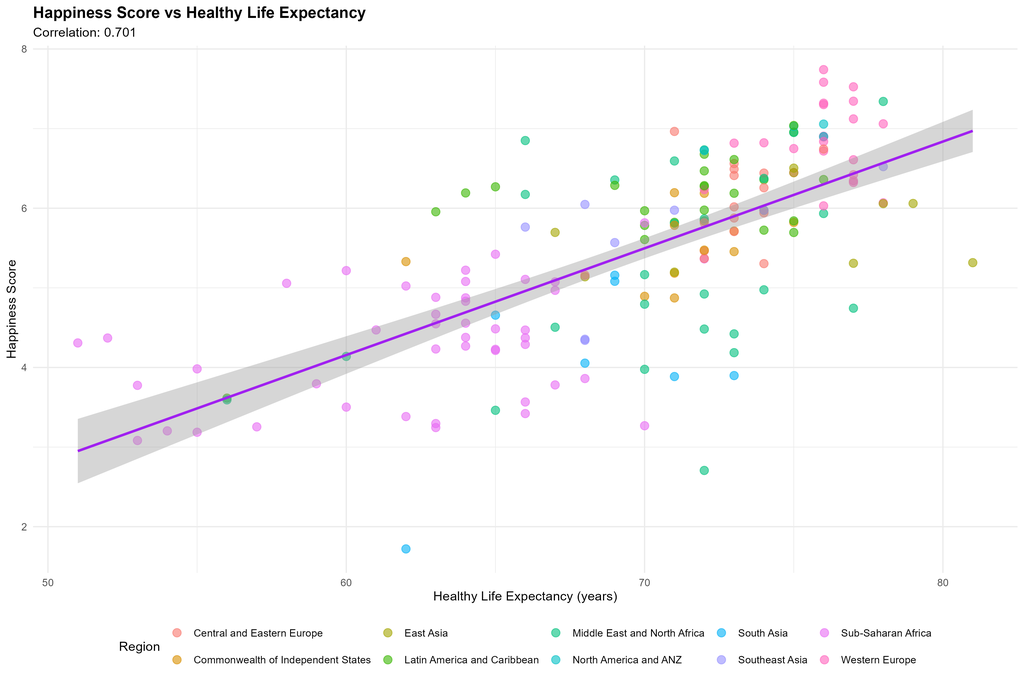

Happiness and Healthy Life Expectancy

**Analysis:**

- **Correlation:** r = 0.701

**Interpretation:**

Healthy life expectancy shows a strong positive correlation with happiness. This relationship reflects:

- **Health Infrastructure:** Countries with better healthcare systems enable longer, healthier lives
- **Quality of Life:** Good health allows people to pursue meaningful activities and relationships
- **Economic Development:** Healthcare quality often correlates with overall development
- **Preventive Care:** Emphasis on prevention leads to better long-term outcomes
- **Bidirectional Effect:** Happier people may also adopt healthier lifestyles

## 5.2 Freedom to Make Life Choices

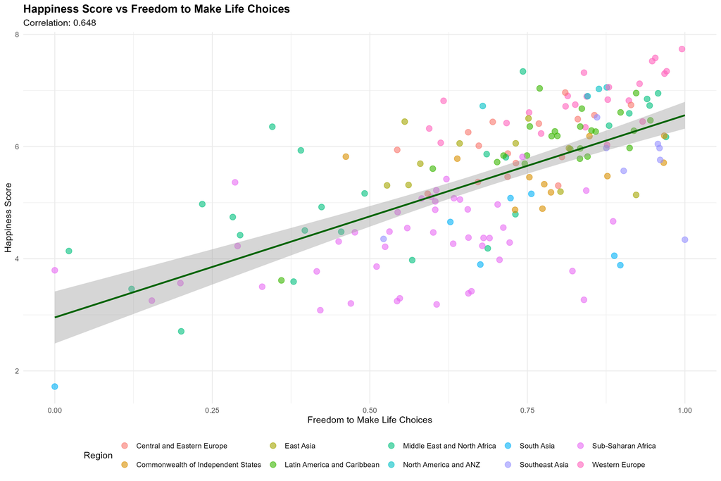

Happiness and Freedom to Make Life Choices

**Analysis:**

- **Correlation:** r = 0.648

**Interpretation:**

Personal freedom strongly predicts happiness, demonstrating that:

- **Autonomy Matters:** People value control over their life decisions
- **Democratic Governance:** Political freedom correlates with personal freedom
- **Economic Freedom:** Ability to choose careers and pursue opportunities
- **Social Freedom:** Liberty to form relationships and express identity
- **Human Rights:** Respect for civil liberties enhances well-being

Countries scoring high on freedom typically have: - Strong rule of law - Protection of individual rights - Democratic institutions - Low corruption - Press freedom

## 5.3 Social Support

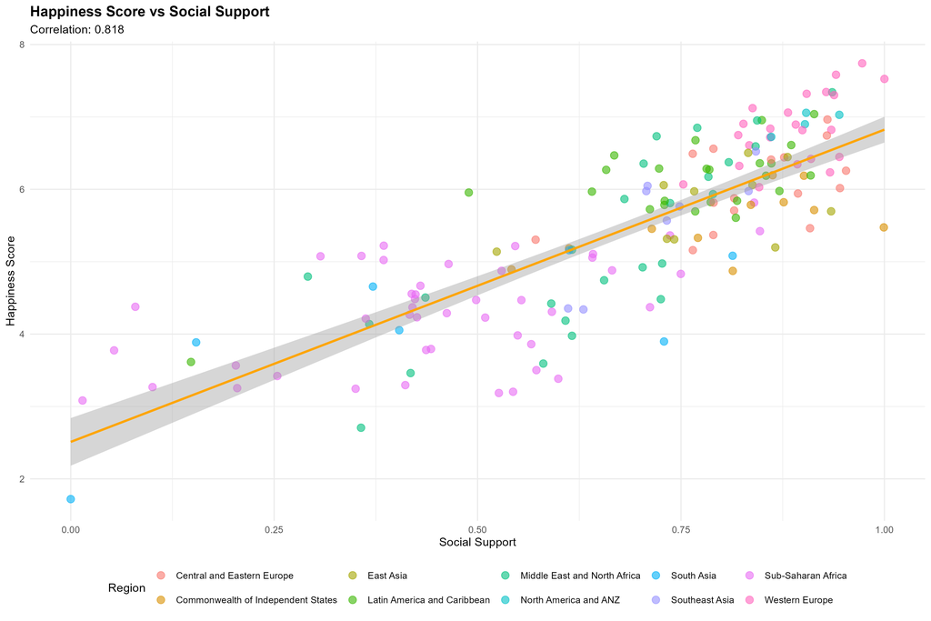

Happiness and Social Support

**Analysis:**

- **Correlation:** r = 0.818 (strongest predictor)

**Interpretation:**

Social support emerges as the **strongest single predictor** of happiness, highlighting that:

- **Relationships Matter Most:** Human connection is fundamental to well-being
- **Safety Net:** Having people to count on during difficult times provides security
- **Community Belonging:** Feeling part of a community enhances life satisfaction
- **Emotional Support:** Sharing experiences and emotions with others is vital
- **Practical Help:** Tangible assistance in times of need reduces stress

This finding has profound policy implications: investments in community building, family support programs, and social cohesion may yield greater happiness returns than purely economic interventions.

# 6 Regional Patterns and Disparities

## 6.1 Regional Comparison

Average Happiness by Region

| Region | Avg Happiness | Avg GDP | Countries |
| --- | --- | --- | --- |
| North America and ANZ | 6.93 | 8.69 | 4 |
| Western Europe | 6.84 | 8.69 | 23 |
| Latin America and Caribbean | 6.07 | 6.33 | 24 |
| Central and Eastern Europe | 6.03 | 7.36 | 16 |
| East Asia | 5.77 | 7.67 | 10 |
| Southeast Asia | 5.57 | 6.51 | 8 |
| Commonwealth of Independent States | 5.54 | 6.42 | 11 |
| Middle East and North Africa | 5.24 | 6.94 | 25 |
| Sub-Saharan Africa | 4.30 | 4.00 | 45 |
| South Asia | 4.07 | 4.90 | 7 |

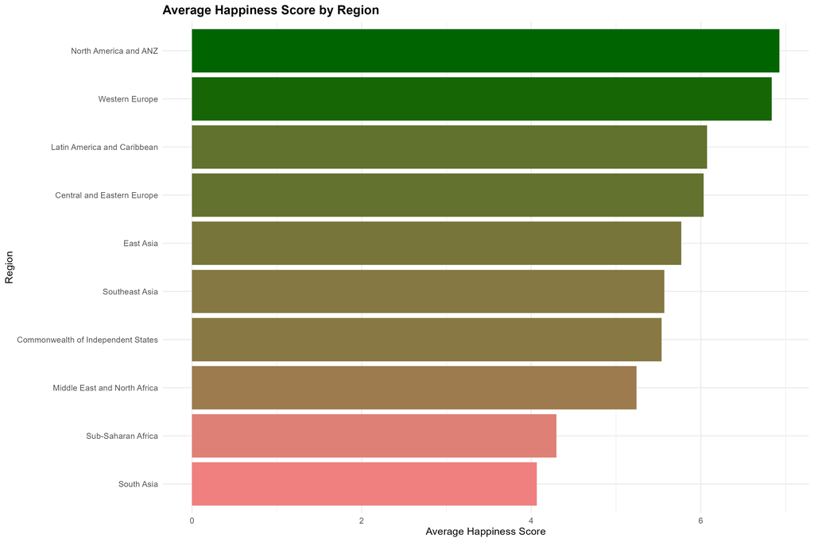

Average Happiness Score by Region

**Interpretation:**

Significant regional disparities exist in happiness levels:

1. **North America and ANZ** leads with an average score of 6.93, reflecting:
   - High economic development
   - Strong democratic institutions
   - Comprehensive welfare systems
   - Low corruption
   - High social trust
2. **Bottom Regions** face multiple challenges:
   - Economic underdevelopment
   - Political instability
   - Weak governance
   - Limited healthcare access
   - Ongoing conflicts
3. **Regional Factors:**
   - **Geographic:** Climate, natural resources, geography influence development
   - **Historical:** Colonial legacies and historical conflicts impact current conditions
   - **Cultural:** Different cultural values shape happiness perceptions
   - **Political:** Governance quality varies dramatically across regions

# 7 Correlation Analysis

## 7.1 Comprehensive Correlation Matrix

[figure not shown]

Correlation Matrix of All Happiness Indicators

**Interpretation:**

The correlation matrix reveals the interconnected nature of happiness factors:

**Strong Positive Correlations (r > 0.60):**

- Social Support ↔︎ Happiness: r = 0.82 (strongest)
- Life Expectancy ↔︎ Happiness: r = 0.7
- GDP ↔︎ Happiness: r = 0.77
- Freedom ↔︎ Happiness: r = 0.65

**Policy Implications:**

Effective interventions should address multiple factors simultaneously rather than focusing on single dimensions.

# 8 Temporal Trends

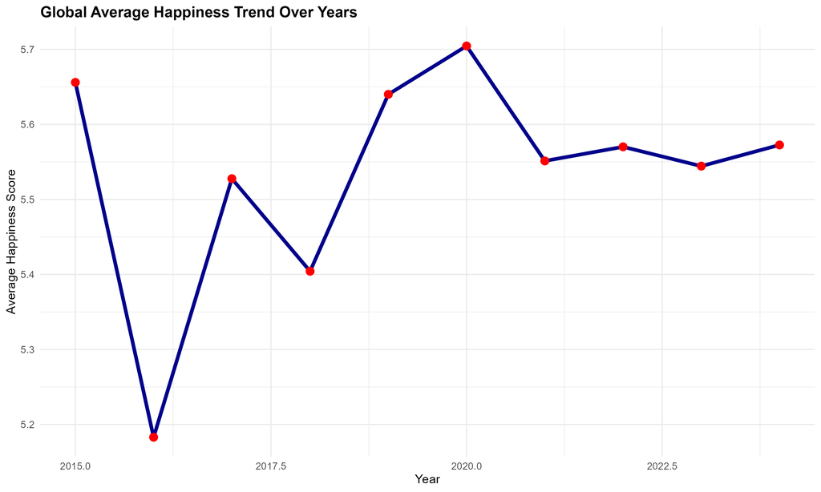

Global Happiness Trends Over Time

[output not shown]

# 9 Country Clustering Analysis

## 9.1 Cluster Identification

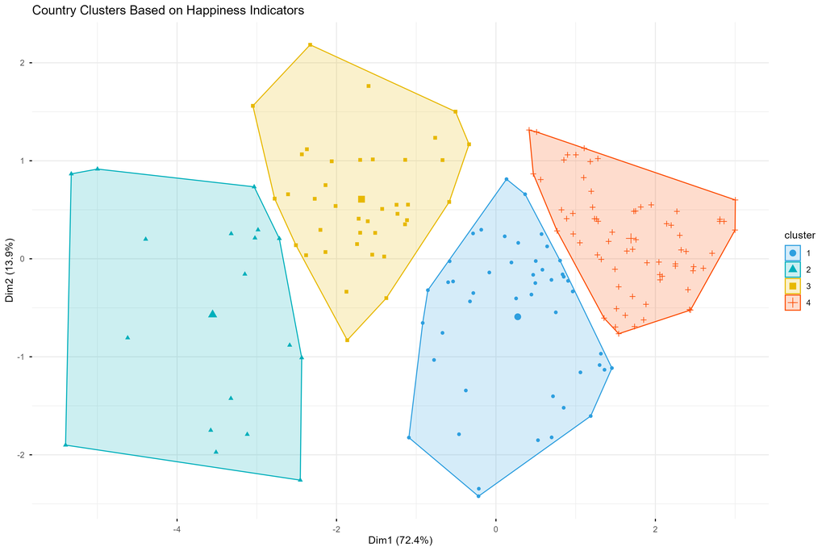

Country Clusters Based on Happiness Indicators

**Methodology:**

K-means clustering grouped countries into 4 distinct clusters based on happiness score, GDP, social support, life expectancy, and freedom.

Cluster Characteristics

| Cluster | Countries | Avg Happiness | Avg GDP | Avg Social Support |
| --- | --- | --- | --- | --- |
| 4 | 69 | 6.54 | 7.95 | 0.85 |
| 1 | 47 | 5.39 | 6.96 | 0.74 |
| 3 | 39 | 4.54 | 4.01 | 0.46 |
| 2 | 18 | 3.43 | 3.28 | 0.35 |

**Interpretation:**

**Cluster 3: Developing Nations** - Characteristics: Lower happiness, limited resources, but potential for growth - Examples: Parts of Asia, Africa, Middle East - Policy Focus: Economic development, governance reform, healthcare investment

# 10 Policy Insights and Recommendations

## 10.1 Key Findings Summary

Based on comprehensive analysis, the following insights emerge:

### 10.1.1 1. Social Support is Paramount

**Finding:** Social support shows the strongest correlation with happiness (r = 0.818).

**Policy Recommendations:**

- **Community Programs:** Invest in community centers, neighborhood associations, and local initiatives
- **Family Support:** Implement family-friendly policies (parental leave, childcare subsidies, flexible work)
- **Social Safety Nets:** Strengthen unemployment benefits, healthcare coverage, and pension systems
- **Mental Health Services:** Expand access to counseling and support groups
- **Volunteer Programs:** Encourage civic engagement and volunteering

**Expected Impact:** Building social cohesion can yield happiness gains even in resource-constrained settings.

### 10.1.2 2. Economic Growth Matters, But Has Limits

**Finding:** GDP correlates with happiness (r = 0.769), but with diminishing returns beyond middle-income levels.

**Policy Recommendations:**

- **For Low-Income Countries:**
  - Prioritize economic development and poverty reduction
  - Invest in infrastructure and education
  - Attract foreign investment and develop industries
- **For Middle/High-Income Countries:**
  - Focus on income distribution rather than just growth
  - Address inequality through progressive taxation
  - Invest in quality of life improvements
  - Promote work-life balance over maximizing GDP

**Expected Impact:** Balanced approach addressing both economic growth and distribution.

### 10.1.3 3. Health Infrastructure is Critical

**Finding:** Life expectancy strongly correlates with happiness (r = 0.701).

**Policy Recommendations:**

- **Universal Healthcare:** Expand access to quality healthcare services
- **Preventive Medicine:** Invest in disease prevention and health education
- **Mental Health Parity:** Treat mental health equally with physical health
- **Active Living:** Create infrastructure for exercise (parks, bike lanes, sports facilities)
- **Health Equity:** Reduce disparities in health outcomes across populations

**Expected Impact:** Healthier populations are happier and more productive.

### 10.1.4 4. Freedom and Good Governance

**Finding:** Freedom to make life choices correlates significantly with happiness (r = 0.648).

**Policy Recommendations:**

- **Democratic Institutions:** Strengthen democratic processes and institutions
- **Anti-Corruption:** Implement robust anti-corruption measures
- **Rule of Law:** Ensure fair and consistent application of laws
- **Civil Liberties:** Protect freedom of speech, assembly, and press
- **Economic Freedom:** Reduce unnecessary regulations, enable entrepreneurship
- **Social Freedom:** Protect individual rights and personal autonomy

**Expected Impact:** Empowered citizens with agency over their lives report higher well-being.

### 10.1.5 5. Address Regional Disparities

**Finding:** Significant happiness gaps exist between regions.

**Policy Recommendations:**

- **International Aid:** Targeted assistance to lowest-performing regions
- **Capacity Building:** Support governance and institutional development
- **Conflict Resolution:** Invest in peace-building and reconciliation
- **Economic Integration:** Facilitate trade and economic cooperation
- **Knowledge Transfer:** Share best practices from high-performing regions

**Expected Impact:** Reducing global inequality benefits all nations through stability and prosperity.

## 10.2 Sector-Specific Recommendations

### 10.2.1 Education

- Invest in quality education accessible to all
- Emphasize social-emotional learning alongside academics
- Develop critical thinking and problem-solving skills
- Promote lifelong learning opportunities

### 10.2.2 Labor and Employment

- Ensure fair wages and safe working conditions
- Promote work-life balance through flexible arrangements
- Protect workers’ rights and collective bargaining
- Invest in job training and career development

### 10.2.3 Urban Planning

- Design cities for livability, not just efficiency
- Create green spaces and recreational areas
- Ensure affordable housing availability
- Develop efficient public transportation

### 10.2.4 Environment

- Address climate change through sustainable policies
- Protect natural resources for future generations
- Promote clean energy and reduce pollution
- Preserve biodiversity and natural habitats

# 11 Limitations and Future Research

## 11.1 Study Limitations

1. **Causality:** Correlational analysis cannot establish causation; happiness may influence predictors as much as predictors influence happiness
2. **Self-Reporting Bias:** Happiness scores rely on self-reports, which can be influenced by cultural norms and momentary moods
3. **Cultural Differences:** What constitutes “happiness” may vary across cultures, affecting comparability
4. **Data Availability:** Some countries lack comprehensive data, potentially skewing global patterns
5. **Temporal Dynamics:** Cross-sectional analysis may miss important temporal dynamics and life-cycle effects

## 11.2 Future Research Directions

1. **Longitudinal Studies:** Track countries over longer periods to understand causal mechanisms
2. **Experimental Interventions:** Conduct randomized controlled trials of happiness-enhancing policies
3. **Cultural Nuances:** Develop culturally-sensitive happiness measures
4. **Individual-Level Analysis:** Examine within-country variations and individual differences
5. **Technology Impact:** Study effects of digitalization and social media on happiness
6. **Climate Change:** Investigate happiness implications of environmental changes

# 12 Conclusion

This comprehensive analysis of global happiness patterns reveals several fundamental truths:

## 12.1 Core Findings

1. **Happiness is Multidimensional:** No single factor determines national happiness. Economic prosperity, social connections, health, freedom, and good governance all contribute significantly.
2. **Social Relationships Trump Economics:** While GDP matters, social support emerges as the strongest predictor of happiness. Human beings are fundamentally social creatures, and our well-being depends critically on the quality of our relationships and communities.
3. **Diminishing Returns of Wealth:** Beyond meeting basic needs, additional income provides progressively smaller happiness gains. This suggests that middle-income countries should balance economic growth with investments in social infrastructure and quality of life.
4. **Regional Disparities Persist:** Large happiness gaps between regions reflect historical, economic, and political differences. Addressing these requires sustained international cooperation and targeted interventions.
5. **Outliers Offer Lessons:** Countries that perform better or worse than their economic level predicts demonstrate that policy choices and cultural values matter enormously.

## 12.2 Overarching Message

**Sustainable happiness requires holistic development across multiple dimensions.** Governments cannot simply pursue GDP growth and expect happiness to follow automatically. Instead, they must simultaneously:

- Foster strong social bonds and community cohesion
- Provide universal healthcare and promote healthy lifestyles
- Ensure political freedoms and good governance
- Reduce corruption and inequality
- Protect the environment for future generations

## 12.3 Call to Action

For policymakers, researchers, and citizens worldwide:

1. **Measure What Matters:** Supplement GDP with happiness and well-being indicators in policy decisions
2. **Invest in Social Capital:** Prioritize programs that build community, strengthen families, and enhance social trust
3. **Learn from Success:** Study and adapt practices from high-performing countries to local contexts
4. **Address Inequality:** Recognize that happiness gaps threaten social cohesion and long-term stability
5. **Think Long-Term:** Make decisions that enhance well-being for current and future generations

## 12.4 Final Thought

The pursuit of happiness is not a luxury—it is a fundamental human aspiration and a legitimate goal of public policy. This analysis demonstrates that happiness is achievable through deliberate policy choices that prioritize human flourishing over narrow economic metrics. The countries that successfully balance economic development with social cohesion, health, freedom, and good governance show us the path forward.

The question is not whether we can build happier societies, but whether we have the wisdom and will to do so.

# 13 Appendix

## 13.1 Statistical Summary

Overall Statistical Summary

|  | Value |
| --- | --- |
| Mean_Happiness | 5.45 |
| SD_Happiness | 1.18 |
| Min_Happiness | 1.72 |
| Max_Happiness | 7.74 |
| Mean_GDP | 6.31 |
| Mean_Social | 0.68 |
| Mean_Life | 69.67 |

## 13.2 Data Sources and Methodology

**Data Source:** World Happiness Report datasets (2015-2024)

**Variables Analyzed:**

- Happiness Score: Self-reported life satisfaction on 0-10 scale
- GDP per Capita: Log of GDP per capita in purchasing power parity
- Social Support: National average of binary responses to having someone to count on
- Healthy Life Expectancy: Average number of years expected to live in good health
- Freedom to Make Life Choices: National average of binary responses about life satisfaction with freedom
- Generosity: Residual of national average of responses on charity donations
- Perceptions of Corruption: Average of binary responses about corruption in government and business

**Analytical Methods:**

- Pearson correlation coefficients
- Linear regression models
- K-means clustering
- Descriptive statistics
- Data visualization

## 13.3 Contact Information

For questions or further analysis, please contact the research team.

**Report Generated:** 2025-11-02

**Analysis Software:** R version R version 4.5.1 (2025-06-13 ucrt)